# Sampling Design for Spatial Cluster Randomized Trials with Spillover and Spatial Dependence

**Andrew J Walther**

Department of Biostatistics, University of North Carolina at Chapel Hill  
PhD Preliminary Oral Exam · December 7, 2026

## Outline

•BackgroundCluster trials of places, spillover, spatial dependence, and what design guidance exists

•MethodsNeighbors, the two allocation designs, the two spillover types, the spatial lag model and the simulation

•Simulation ResultsWhere block stratified sampling falls among random allocations, and why

•ApplicationProbation trials across North Carolina judicial districts

•DiscussionChoosing a design, take-home, limitations and next steps

## When a program is delivered to whole communities, trials randomize places, and places have neighbors

- A **cluster randomized trial (CRT)** assigns whole groups, here geographic areas, to intervention or control
- It is the natural design when a program, policy or supervision practice is delivered to an area rather than to one person
- Geographic clusters share borders, so what happens in one area can depend on its neighbors
- Two separate mechanisms create that dependence, **spillover** and **spatial dependence**, and both affect how well a trial can estimate its effect
- This project began with two planned **probation trials** in North Carolina that randomize counties or districts

Intervention areaControl areaPossible spillover

## Treatment can spill over into neighboring untreated areas

### Bed nets, northern Ghana

Child mortality was lower in control villages near villages given insecticide-treated bed nets than in more distant control villages.

### School deworming, western Kenya

Untreated children attending schools near treated schools had fewer worm infections.

Spillover is a treatment effect that crosses a cluster boundary

- A standard CRT analysis assumes a cluster’s outcome depends only on its own assignment
- When treatment reaches control neighbors, controls look better than they would have, and the intervention–control difference understates the effect
- How far and to whom it spreads depends on the program, so a design has to state its assumption

Binka et al., Am J Trop Med Hyg 1998; Miguel and Kremer, Econometrica 2004.

## Neighboring outcomes are also correlated for reasons that have nothing to do with treatment

Spatial dependence ($\rho$)

Neighbors have similar outcomes because they share conditions, with or without treatment

Spillover ($\psi$)

The treated area (dark) raises outcomes in its neighbors (amber); without treatment there is none

- Both run through the same neighbors, so they are easy to confuse, and the model keeps them as separate parameters
- Spatial dependence breaks the independence a standard analysis assumes and can understate standard errors

## Spatial methods mostly adjust after the data are in, and guidance on which clusters to treat is thin

**1. Before the trial (design)**Choose which clusters to treat

- Restricted randomization balances covariates, and recent versions spread the selected clusters apart
- Buffer zones drop areas near the boundary between arms
- Saturation designs vary the treated share across groups

→

**2. During the trial**Treatment reaches neighbors, and neighboring outcomes move together

- Spillover ($\psi$)
- Spatial dependence ($\rho$)

→

**3. After the trial (analysis)**Adjust for space

- Exposure measures, such as distance to the nearest treated area
- Spatial models of the mean or covariance
- These choices can change the estimate and its uncertainty

### The gap

Few studies compare simple allocation rules in step 1 when spillover and spatial dependence occur together.

### Why step 1 matters

If every control district borders a trained district, no analysis in step 3 can tell the training apart from being next to it.

Jarvis et al., Emerg Themes Epidemiol 2017; Silcocks and Kendrick, Trials 2010; Chao et al., Epidemiol Infect 2015; Moulton, Clin Trials 2004; Crisp et al., Clin Trials 2023; McCann et al., Int J Epidemiol 2018; Baird et al., Rev Econ Stat 2018.

## Does the allocation chosen before the trial change how well we estimate the effect?

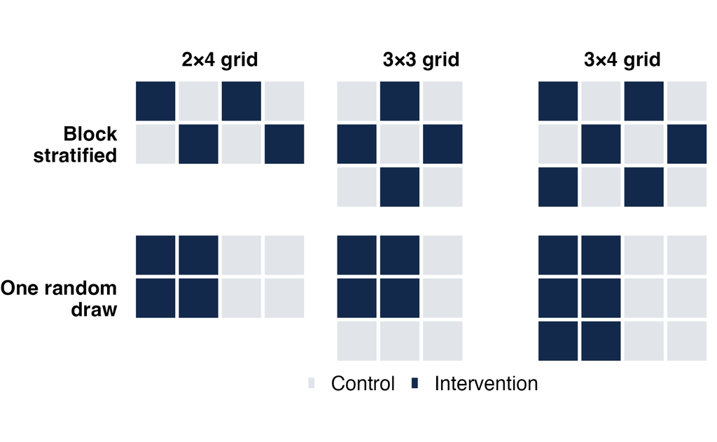

Dark cells are intervention clusters. The three grids studied here.

### Simple random sampling (SRS)

Any allocation with half the clusters treated (4 of 9 on the 3×3 grid), drawn at random. It can put all treated clusters together, as in the bottom row.

### Block stratified sampling (BSS)

No two intervention clusters share an edge, and no two controls where the grid allows. That leaves the two checkerboards on the 2×4 and 3×4 grids, and 6 allocations on the 3×3 grid, where only intervention clusters must be separated.

- An **allocation** is the list of which clusters get the intervention
- We compare designs by the **mean squared error (MSE)** of the intervention effect estimate, how far off the estimate tends to be from bias and chance together. Smaller is better

## This study defines neighbors as clusters that share an edge

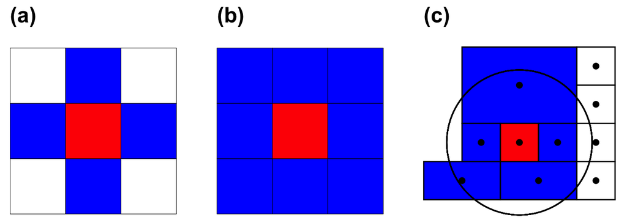

- **Rook** neighbors share an edge, **queen** neighbors share an edge or a corner, and higher-order neighbors are neighbors of neighbors
- Distance-based neighbors lie within a fixed radius
- We use **rook** neighbors throughout, the same edge rule that defines BSS, and they decide both who can receive spillover and who is spatially correlated

## Spillover may reach only control clusters, or control and intervention clusters

Control Clusters Only

Control & Intervention Clusters

Intervention cluster ($x_i = 1$)Control cluster ($x_i = 0$)Exposed to spillover ($z_i = 1$), unmarked $z_i = 0$

- Exposure is **binary**. A cluster is exposed if at least one rook neighbor is an intervention cluster (and, for Control Clusters Only, it is itself a control), however many treated neighbors it has
- **Control Clusters Only** is classic contamination; under **Control & Intervention Clusters** treated clusters next to other treated clusters gain extra

## A spatial lag model separates the intervention effect, spillover and spatial dependence

$$y_i \;=\; \alpha \;+\; \beta\, x_i \;+\; \psi\, z_i \;+\; \rho \sum_{j \in \mathcal{N}(i)} w_{ij}\, y_j \;+\; \varepsilon_i,
\qquad \varepsilon_i \overset{iid}{\sim} N(0, \sigma^2)$$

Control Clusters Only $z_i = 1$ if $x_i = 0$ and $x_j = 1$ for some $j \in \mathcal{N}(i)$ Control & Intervention Clusters $z_i = 1$ if $x_j = 1$ for some $j \in \mathcal{N}(i)$

$y_i$Cluster-level outcome of cluster $i$ $\alpha$Baseline effect (0.2 in the simulation) $x_i$Treatment indicator, 1 if cluster $i$ is an intervention cluster, 0 if control $\beta$Intervention effect, the target of estimation (1.0) $z_i$Binary spillover indicator, defined for each spillover type above $\psi$Spillover effect, a scalar coefficient on $z_i$ (0.5, 0.6, 0.7 or 0.8) $\mathcal{N}(i)$Rook neighbors of cluster $i$, the clusters sharing an edge with it $\rho$Spatial dependence (autocorrelation) coefficient (0 or 0.01; its scale is in backup) $\varepsilon_i$Independent normal error (subject-level SD $\sigma = 0.1$) $w_{ij}$Row-normalized weight, $1/|\mathcal{N}(i)|$ for each rook neighbor $j$ and 0 otherwise, so the sum is the average of the neighbors’ outcomes

Subjects are placed at random over the grid (160 per replication on the 2×4 grid, about 20 per cluster). Every subject in a cluster shares its $x_i$, $z_i$ and neighbors, and outcomes vary within a cluster only through independent error, so the model is written for the cluster-level outcome $y_i$. Fitted by maximum likelihood (`lagsarlm`) with the true spillover term included wherever the allocation lets it be estimated; $\beta$, $\psi$ and $\rho$ are structural coefficients.

## Outcomes are generated with y on both sides, so effects ripple through the neighbors

$$\mathbf{y} = \rho\mathbf{W}\mathbf{y} + \boldsymbol\alpha + \mathbf{X}\beta + \mathbf{Z}\psi + \boldsymbol\varepsilon
\quad\Longrightarrow\quad
\mathbf{y} = (\mathbf{I} - \rho\mathbf{W})^{-1}\left(\boldsymbol\alpha + \mathbf{X}\beta + \mathbf{Z}\psi + \boldsymbol\varepsilon\right)$$

$$(\mathbf{I} - \rho\mathbf{W})^{-1} = \mathbf{I} + \rho\mathbf{W} + \rho^2\mathbf{W}^2 + \cdots$$

- The matrix form stacks the clusters: $\mathbf{X}$ and $\mathbf{Z}$ hold each cluster’s $x_i$ and $z_i$, and $\mathbf{W}$ holds the weights $w_{ij}$
- Since $\mathbf{y}$ appears on both sides, outcomes are simulated from the solved (reduced) form on the right
- The expansion shows the ripple: each cluster’s outcome passes to its neighbors ($\rho\mathbf{W}$), their neighbors ($\rho^2\mathbf{W}^2$) and so on
- The model is fitted by maximum likelihood; the likelihood is in backup

## We enumerate every possible allocation on three small grids and compare their error

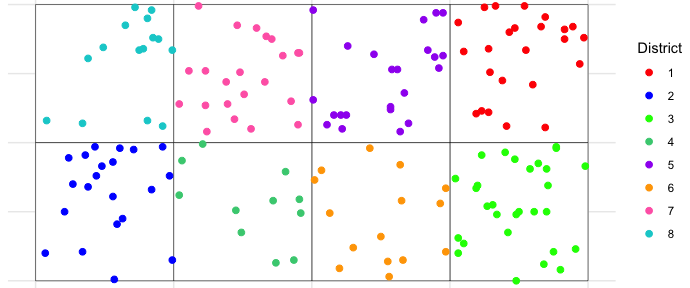

One replication on the 2×4 grid, 160 subjects placed at random. Only cluster membership enters the fit.

| Grid | Clusters | Allocations (SRS) | BSS allocations | Replications |
| --- | --- | --- | --- | --- |
| 2×4 | 8 | 70 | 2 | 50 |
| 3×3 | 9 | 126 | 6 | 50 |
| 3×4 | 12 | 924 | 2 | 10 |

- 16 scenarios per grid: $\psi \in \{0.5, 0.6, 0.7, 0.8\}$ × $\rho \in \{0, 0.01\}$ × two spillover types
- Outcomes generated from the model’s reduced form, $\beta$ estimated in every replication $r = 1, \dots, N$
- For each allocation, bias $= \bar{\hat\beta} - \beta$, variance $= \frac{1}{N}\sum_r(\hat\beta_r - \bar{\hat\beta})^2$, and $\text{MSE} = \frac{1}{N}\sum_{r}(\hat\beta_r - \beta)^2 = \text{bias}^2 + \text{variance}$
- A design is summarized by the **mean MSE over its allocations** and by **how much that MSE varies** across allocations (SD of MSE)

## With spillover into controls and correlated outcomes, block stratified sampling beats about half of random draws and avoids the worst ones

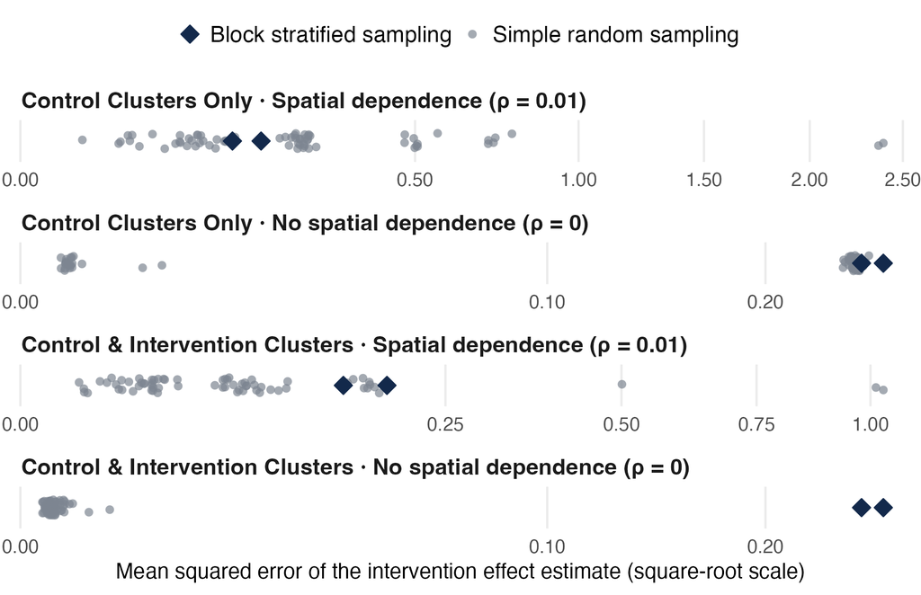

Each dot is one allocation’s MSE over its replications (2×4 grid, ψ = 0.5). Further left is better. Each row has its own scale.

57%  
of random allocations have higher MSE than BSS with spillover into controls and $\rho = 0.01$ (2×4, $\psi = 0.5$)

- The worst tenth of random draws average MSE **1.20**, and the worst is **2.39**; neither BSS allocation exceeds **0.19**
- Across all grids and $\psi$ in that setting, BSS beats **40–60%** of random draws
- On this grid, without spatial dependence most random draws tie BSS (they also expose every control); with spillover into both arms, most do better

## With spillover into controls only, block stratified sampling has lower error when outcomes are spatially correlated

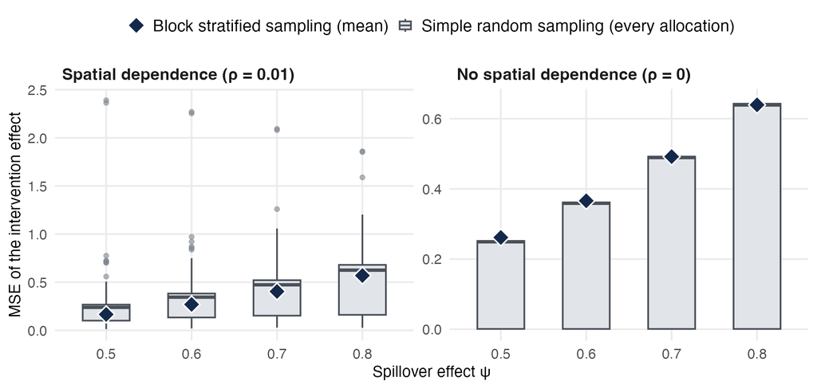

**With ρ = 0.01,** BSS **0.165** vs SRS **0.304** ($\psi = 0.5$), lower at every $\psi$, with the gap closing by $\psi = 0.8$ (0.569 vs 0.573)

**With ρ = 0,** SRS is lower on average, **0.173** vs **0.262**

**Spread across allocations,** SD of MSE **0.41** for random draws; BSS is effectively one allocation here (two mirror-image checkerboards)

## With spillover into both arms, simple random sampling has the lower average error

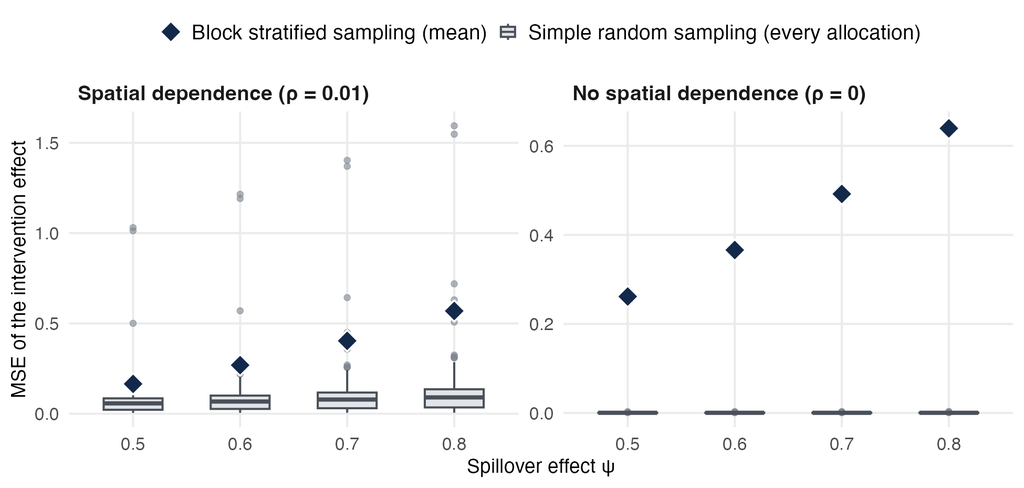

- SRS is lower in **all 24 of 24** such scenarios across the three grids, for example **0.095 vs 0.165** with $\rho = 0.01$ and **0.008 vs 0.262** with $\rho = 0$ (2×4, $\psi = 0.5$)
- BSS results are identical under both spillover types on every grid, since no treated cluster has a treated neighbor

## With spillover into controls only, an allocation that exposes every control makes exposure the exact opposite of treatment

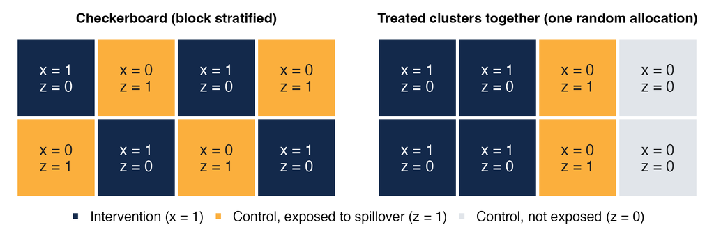

- Under Control Clusters Only, if every control is exposed then $z_i = 1 - x_i$ for every cluster, $[\mathbf{1}, x, z]$ loses rank, and $\beta$ and $\psi$ cannot be separated. `lagsarlm` drops $z$, and $\hat\beta$ estimates $\beta - \psi$
- At $\rho = 0$ the 2×4 BSS bias is $-\psi$ (**-0.50** to **-0.80**); with spatial dependence the lag term absorbs part of it (**-0.35** to **-0.72**)
- **Control Clusters Only.** Every checkerboard and many random allocations are collinear (**48 of 70** on 2×4, 57 of 126 on 3×3, 488 of 924 on 3×4)
- **Control & Intervention Clusters.** Only the checkerboards are (2, 1 and 2), so random draws almost always keep the information, and SRS wins
- Collinearity can be checked from the map before the trial

## The same pattern holds on the 3×3 and 3×4 grids

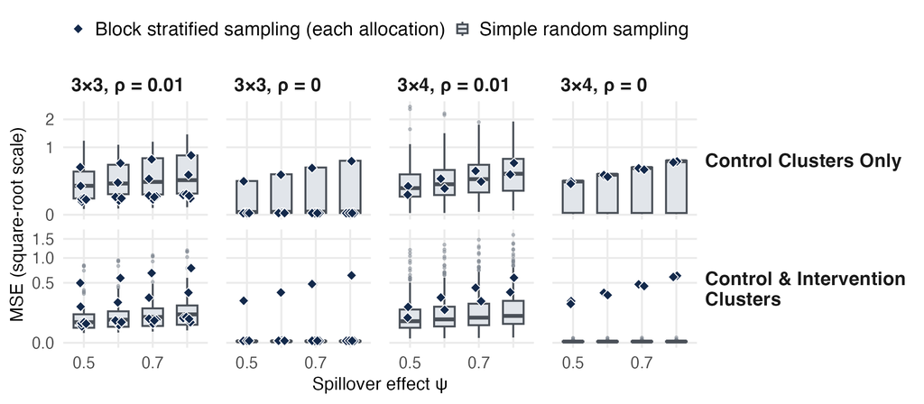

- The better design matches the 2×4 grid in **16 of 16** scenarios on 3×4 and **12 of 16** on 3×3. The exception (3×3, spillover into controls, $\rho = 0$) has five BSS allocations that leave a control unexposed
- Random draws spread widely. On 3×4 with spillover into controls and $\rho = 0.01$ they reach MSE **2.57**, while both BSS allocations stay at or below **0.18** ($\psi = 0.5$)

## North Carolina probation trials assign counties or judicial districts, natural spatial clusters

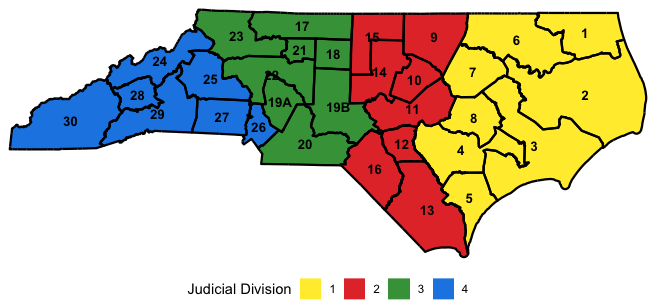

- **30 judicial districts** in **4 divisions** (NC Division of Community Supervision)
- Chief probation/parole officers and district managers oversee districts, often spanning several counties
- **Case 1, trauma-informed supervision.** Training for officers and chiefs on specialty caseloads, randomized by county or district
- Neighbors share courts, labor markets and providers, and leaders and providers can carry the program across arms

## A second study crosses the four behavioral health management areas

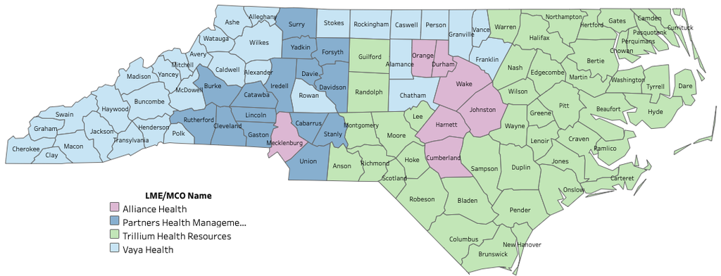

Each county shaded by the LME/MCO that manages its behavioral health services.

- **Case 2, specialty mental health probation.** Cross-training and joint treatment-team meetings between officers and behavioral health providers
- Each county is served by one of **4 LME/MCOs** (Local Management Entity/Managed Care Organizations)
- Large providers work across counties and MCO areas, so practices can travel into control counties
- MCO-level policies are a confounder, so the design stratifies by MCO area

## For both studies we recommend a best-effort block stratified allocation

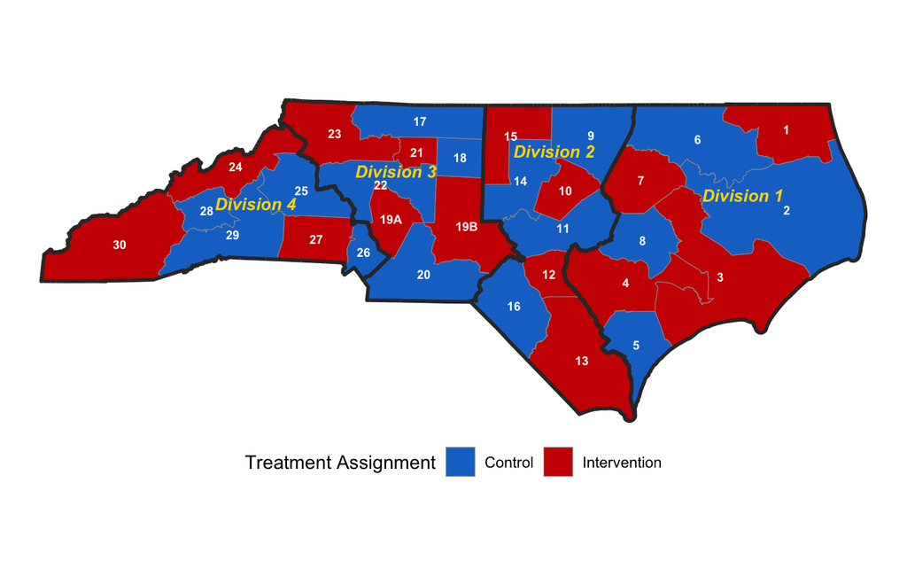

An example allocation of judicial districts (Case 1). Red, intervention; blue, control. Case 2 would do the same with counties within each MCO area.

- Stratify by judicial division (Case 1) or MCO area (Case 2), then keep same-arm districts apart where the map allows
- Why controls only? With a consistent treatment effect, treated districts gain nothing more from other treated districts, but nearby controls can pick the program up
- This is a suggested, best-effort allocation for an irregular map. A refined allocation could also leave a few control districts with no intervention neighbor, which keeps the program and its spillover separable
- In Case 2, a provider who joins the training may serve several counties, carrying it into control counties as well. If treated districts were instead expected to reinforce each other, SRS would be the better choice

## Match the design to the spillover and spatial correlation you expect

|  | Neighboring outcomes move together (ρ = 0.01) | Neighboring outcomes independent (ρ = 0) |
| --- | --- | --- |
| Spillover into control clusters only | **Block stratified sampling.** Lower MSE in 12 of 12 scenarios across grids (near ties at ψ = 0.8) (2×4: 0.165 vs 0.304), and it avoids the worst random draws | **SRS, or BSS only if some controls border no intervention cluster** (never true of a strict checkerboard). What decides it is whether the allocation leaves controls unexposed |
| Spillover into control and intervention clusters | **Simple random sampling** (2×4: 0.095 vs 0.165), or a buffer-zone design (not evaluated here) | **Simple random sampling.** Lower in every scenario (2×4: 0.008 vs 0.262) |

2×4 values at ψ = 0.5; the direction holds across ψ. For probation districts, which share courts, providers and labor markets, the first column is the realistic one.

## Block stratified sampling is a good design, not the best or the worst, against rolling the dice on one random draw

Choose the allocation for the spillover you expect, and know what a single random draw can cost

### Risk, not just the average

SRS can win on average, but one trial runs one allocation, and some random draws estimate the effect poorly.

### The spillover type matters

BSS helps most when spillover flows into controls and outcomes are spatially correlated, and most random allocations beat it when spillover reaches both arms.

### State the mechanism

Justify the design by the anticipated direction of spillover, and look at which controls the chosen allocation exposes. If every control borders an intervention cluster, expect the estimate to understate the effect, and where the map allows, keep a few controls clear of treated neighbors.

## These results come from small regular grids and a simple spillover model

### Limitations

- Treatment and spillover are exactly collinear whenever every control is exposed, which includes every checkerboard
- Binary rook spillover, with no decay over distance and no added effect from more treated neighbors
- Small regular grids of equal-area clusters
- No intra-cluster correlation; results specific to the spatial lag model with the spillover term included

### Next steps

- Distance-decaying and additive spillover
- Buffer-zone designs that keep some controls unexposed
- Larger, irregular geographies and more designs
- Model misspecification and other spatial models

Walther A, Van Deinse T, Lin F-C. Spatial cluster randomized trials: sampling design with spillover effects and spatial dependence. *BMC Medical Research Methodology* (2026). doi:10.1186/s12874-026-02968-0

## Thank you!

#### Advisor

Feng-Chang Lin

#### Collaborator

Tonya Van Deinse

#### Funding

National Institute of Mental Health, K01MH129619 (Dr. Van Deinse)  
Bureau of Justice Assistance, 15PBJA-24-GG-01896-PRJH (NC Department of Adult Correction)

#### Paper

Walther et al., *BMC Medical Research Methodology* (2026)

Questions welcome

awalther@unc.edu

## Backup · 3×3 grid, every allocation

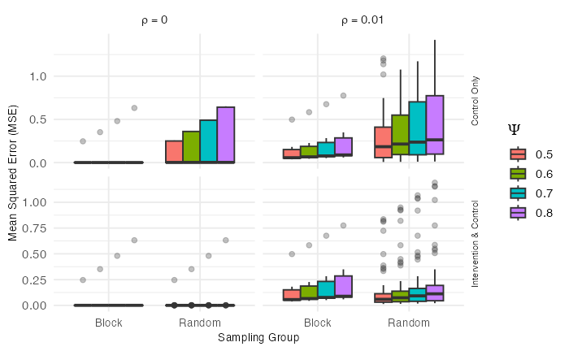

- Rows are spillover types (Control Only on top), columns are $\rho$. “Block” is the six BSS allocations and “Random” every allocation, colored by $\psi$
- The BSS spread comes from its six different allocations. One, the full checkerboard, is collinear; the other five leave a control unexposed and estimate $\beta$ almost exactly
- With spillover into controls and $\rho = 0.01$, random allocations reach MSE 1.20 at $\psi = 0.5$, against at most 0.50 for BSS

## Backup · 3×4 grid, every allocation

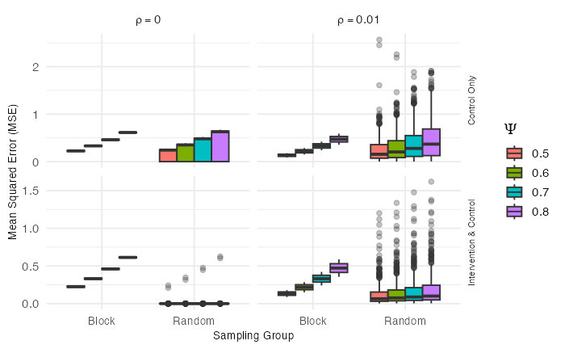

- Rows are spillover types (Control Only on top), columns are $\rho$. “Block” is the two checkerboards and “Random” all 924 allocations, colored by $\psi$
- With spillover into controls and $\rho = 0.01$, random allocations reach MSE 2.57 at $\psi = 0.5$, while both checkerboards stay at or below 0.18
- With spillover into both arms, most random allocations sit near zero and the checkerboards do not

## Backup · Where block stratified sampling falls among random allocations, every grid and setting

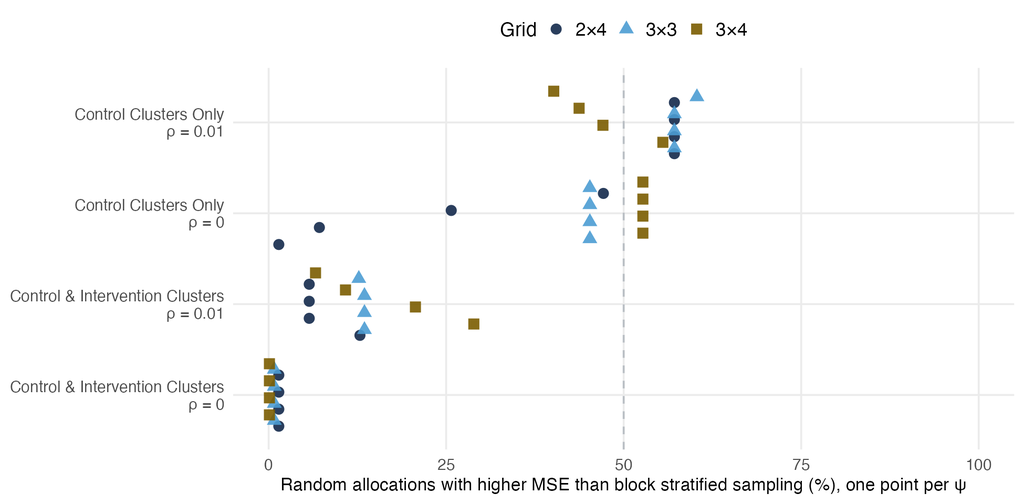

One point per ψ; points that share a value overlap. With ρ = 0 and spillover into controls, most draws expose every control and estimate β − ψ like BSS, so the share there splits near-ties by simulation noise.

## Backup · A good random draw can beat the checkerboard, but it cannot be picked before the trial

- Spillover into controls, $\rho = 0.01$, $\psi = 0.5$. The allocation is chosen before any outcome is seen, so the relevant comparison is with the whole spread of random draws
- 2×4: BSS MSE **0.165**; the worst tenth of random draws average **1.20**, about 7 times as large (3×3: 0.147 vs 0.84; 3×4: 0.133 vs 0.77)
- Random draws that leave some control unexposed keep $\beta$ and $\psi$ separate, and many of them beat BSS (on 2×4, BSS beats 2 of 22; on 3×4, 151 of 436)
- But that check does not protect against a bad draw. The worst draw on each grid passes it (2×4: MSE 2.39, half the grid treated as one block; 3×4: 2.57)
- Which random draw will do best can only be known after the fact. BSS gives a reasonable error with a bounded downside, which is the trade an investigator can make in advance

## Backup · Full results, 2×4 grid

| Spillover into | ρ | ψ | SRS MSE | SRS SD | SRS bias | BSS MSE | BSS SD | BSS bias |
| --- | --- | --- | --- | --- | --- | --- | --- | --- |
| Control only | 0.01 | 0.5 | 0.304 | 0.405 | -0.270 | 0.165 | 0.029 | -0.349 |
| Control only | 0.01 | 0.6 | 0.382 | 0.406 | -0.342 | 0.269 | 0.046 | -0.471 |
| Control only | 0.01 | 0.7 | 0.471 | 0.414 | -0.414 | 0.404 | 0.065 | -0.594 |
| Control only | 0.01 | 0.8 | 0.573 | 0.439 | -0.486 | 0.569 | 0.087 | -0.716 |
| Control only | 0 | 0.5 | 0.173 | 0.117 | -0.343 | 0.262 | 0.009 | -0.496 |
| Control only | 0 | 0.6 | 0.248 | 0.168 | -0.411 | 0.366 | 0.010 | -0.597 |
| Control only | 0 | 0.7 | 0.338 | 0.229 | -0.480 | 0.492 | 0.010 | -0.697 |
| Control only | 0 | 0.8 | 0.441 | 0.299 | -0.548 | 0.639 | 0.008 | -0.798 |
| Control & Intervention | 0.01 | 0.5 | 0.095 | 0.176 | 0.031 | 0.165 | 0.029 | -0.349 |
| Control & Intervention | 0.01 | 0.6 | 0.115 | 0.208 | 0.030 | 0.269 | 0.046 | -0.471 |
| Control & Intervention | 0.01 | 0.7 | 0.138 | 0.242 | 0.029 | 0.404 | 0.065 | -0.594 |
| Control & Intervention | 0.01 | 0.8 | 0.162 | 0.279 | 0.027 | 0.569 | 0.087 | -0.716 |
| Control & Intervention | 0 | 0.5 | 0.008 | 0.044 | -0.014 | 0.262 | 0.009 | -0.496 |
| Control & Intervention | 0 | 0.6 | 0.011 | 0.061 | -0.017 | 0.366 | 0.010 | -0.597 |
| Control & Intervention | 0 | 0.7 | 0.015 | 0.082 | -0.020 | 0.492 | 0.010 | -0.697 |
| Control & Intervention | 0 | 0.8 | 0.019 | 0.107 | -0.023 | 0.639 | 0.008 | -0.798 |

MSE, SD of MSE across allocations, and mean bias of $\hat\beta$. Shading marks the design with lower MSE. SD here is the spread of MSE across allocations, unscaled (the chapter reports it ×10). The two 2×4 checkerboards are mirror images, so their difference (0.144 vs 0.186 at ρ = 0.01, ψ = 0.5) is a guide to the Monte Carlo error.

## Backup · Full results, 3×3 grid

| Spillover into | ρ | ψ | SRS MSE | SRS SD | SRS bias | BSS MSE | BSS SD | BSS bias |
| --- | --- | --- | --- | --- | --- | --- | --- | --- |
| Control only | 0.01 | 0.5 | 0.274 | 0.263 | -0.089 | 0.147 | 0.180 | -0.054 |
| Control only | 0.01 | 0.6 | 0.330 | 0.296 | -0.135 | 0.174 | 0.211 | -0.064 |
| Control only | 0.01 | 0.7 | 0.390 | 0.347 | -0.181 | 0.205 | 0.246 | -0.073 |
| Control only | 0.01 | 0.8 | 0.455 | 0.414 | -0.227 | 0.240 | 0.284 | -0.083 |
| Control only | 0 | 0.5 | 0.114 | 0.125 | -0.226 | 0.042 | 0.100 | -0.078 |
| Control only | 0 | 0.6 | 0.164 | 0.180 | -0.271 | 0.059 | 0.143 | -0.096 |
| Control only | 0 | 0.7 | 0.223 | 0.245 | -0.316 | 0.081 | 0.196 | -0.113 |
| Control only | 0 | 0.8 | 0.291 | 0.320 | -0.362 | 0.106 | 0.258 | -0.130 |
| Control & Intervention | 0.01 | 0.5 | 0.103 | 0.148 | 0.071 | 0.147 | 0.180 | -0.054 |
| Control & Intervention | 0.01 | 0.6 | 0.122 | 0.169 | 0.082 | 0.174 | 0.211 | -0.064 |
| Control & Intervention | 0.01 | 0.7 | 0.143 | 0.191 | 0.092 | 0.205 | 0.246 | -0.073 |
| Control & Intervention | 0.01 | 0.8 | 0.167 | 0.213 | 0.102 | 0.240 | 0.284 | -0.083 |
| Control & Intervention | 0 | 0.5 | 0.002 | 0.022 | -0.004 | 0.042 | 0.100 | -0.078 |
| Control & Intervention | 0 | 0.6 | 0.003 | 0.031 | -0.004 | 0.059 | 0.143 | -0.096 |
| Control & Intervention | 0 | 0.7 | 0.004 | 0.043 | -0.005 | 0.081 | 0.196 | -0.113 |
| Control & Intervention | 0 | 0.8 | 0.005 | 0.056 | -0.006 | 0.106 | 0.258 | -0.130 |

As for the 2×4 table. The 3×3 grid has six BSS allocations, not all checkerboards, so BSS MSE also varies across allocations.

## Backup · Full results, 3×4 grid

| Spillover into | ρ | ψ | SRS MSE | SRS SD | SRS bias | BSS MSE | BSS SD | BSS bias |
| --- | --- | --- | --- | --- | --- | --- | --- | --- |
| Control only | 0.01 | 0.5 | 0.244 | 0.244 | -0.190 | 0.133 | 0.064 | -0.273 |
| Control only | 0.01 | 0.6 | 0.311 | 0.289 | -0.242 | 0.218 | 0.095 | -0.391 |
| Control only | 0.01 | 0.7 | 0.390 | 0.349 | -0.292 | 0.331 | 0.128 | -0.509 |
| Control only | 0.01 | 0.8 | 0.480 | 0.425 | -0.341 | 0.472 | 0.164 | -0.627 |
| Control only | 0 | 0.5 | 0.133 | 0.125 | -0.264 | 0.226 | 0.023 | -0.463 |
| Control only | 0 | 0.6 | 0.191 | 0.180 | -0.317 | 0.332 | 0.022 | -0.570 |
| Control only | 0 | 0.7 | 0.260 | 0.245 | -0.370 | 0.461 | 0.020 | -0.676 |
| Control only | 0 | 0.8 | 0.339 | 0.320 | -0.423 | 0.614 | 0.017 | -0.782 |
| Control & Intervention | 0.01 | 0.5 | 0.112 | 0.129 | 0.022 | 0.133 | 0.064 | -0.273 |
| Control & Intervention | 0.01 | 0.6 | 0.131 | 0.148 | 0.021 | 0.218 | 0.095 | -0.391 |
| Control & Intervention | 0.01 | 0.7 | 0.151 | 0.168 | 0.020 | 0.331 | 0.128 | -0.509 |
| Control & Intervention | 0.01 | 0.8 | 0.173 | 0.190 | 0.018 | 0.472 | 0.164 | -0.627 |
| Control & Intervention | 0 | 0.5 | 0.001 | 0.011 | -0.001 | 0.226 | 0.023 | -0.463 |
| Control & Intervention | 0 | 0.6 | 0.001 | 0.015 | -0.001 | 0.332 | 0.022 | -0.570 |
| Control & Intervention | 0 | 0.7 | 0.001 | 0.021 | -0.002 | 0.461 | 0.020 | -0.676 |
| Control & Intervention | 0 | 0.8 | 0.002 | 0.029 | -0.002 | 0.614 | 0.017 | -0.782 |

As for the 2×4 table. 10 replications per allocation on this grid.

## Backup · Outcomes come from the reduced form, and the model is fitted by maximum likelihood

$$\mathbf{y} = \rho \mathbf{W}\mathbf{y} + \boldsymbol\alpha + \mathbf{X}\beta + \mathbf{Z}\psi + \boldsymbol\varepsilon
\;\Longrightarrow\;
\mathbf{y} = (\mathbf{I} - \rho\mathbf{W})^{-1}\left(\boldsymbol\alpha + \mathbf{X}\beta + \mathbf{Z}\psi + \boldsymbol\varepsilon\right),
\;\; \boldsymbol\varepsilon \sim N(\mathbf{0}, \sigma^2\mathbf{I})$$

$$\ell(\alpha, \beta, \psi, \rho, \sigma^2) = -\frac{n}{2}\log(2\pi\sigma^2) + \log\left|\mathbf{I} - \rho\mathbf{W}\right|
- \frac{1}{2\sigma^2}\left(\mathbf{A}\mathbf{y} - \mathbf{D}\boldsymbol\theta\right)^\top\left(\mathbf{A}\mathbf{y} - \mathbf{D}\boldsymbol\theta\right)$$

- $\mathbf{A} = \mathbf{I} - \rho\mathbf{W}$, $\mathbf{D} = [\mathbf{1}, \mathbf{X}, \mathbf{Z}]$, $\boldsymbol\theta = (\alpha, \beta, \psi)^\top$, and $n$ is the number of observations (in the simulation, the subjects, 160 on the 2×4 grid)
- For fixed $\rho$, $\boldsymbol\theta$ and $\sigma^2$ have closed forms, and $\rho$ maximizes the concentrated likelihood (`lagsarlm()` in R)
- A change in one cluster’s treatment reaches every cluster through the spatial multiplier $(\mathbf{I} - \rho\mathbf{W})^{-1}$
- When $z = 1 - x$, $\mathbf{D}$ is rank-deficient and $\beta$, $\psi$ are not separately identified. Under Control & Intervention Clusters, $z \equiv 1$ in 16, 16 and 126 allocations; then $\psi$ is aliased with $\alpha$ and $\beta$ is unaffected
- In the simulation code the generating $\mathbf{W}$ is subject-level and binary (see the ρ backup)

## Backup · Row-normalized rook weights make the lag term a neighbor average

Cells numbered row by row for this example; cluster 2 and its rook neighbors (amber).

$$w_{ij} = \frac{c_{ij}}{\sum_k c_{ik}}, \qquad c_{ij} = \begin{cases} 1 & \text{edge shared} \\ 0 & \text{otherwise} \end{cases}$$

- Cluster 2 has rook neighbors 1, 3 and 6, so $w_{21} = w_{23} = w_{26} = 1/3$
- Each row sums to 1, so $\sum_j w_{ij} y_j$ is the average neighbor outcome and $\rho$ is comparable across clusters with different numbers of neighbors
- The same rook structure defines $z_i$, so spillover and spatial dependence share one neighbor definition

## Backup · How large is ρ = 0.01?

- In the simulation code, outcomes were generated for the subjects with **subject-level binary weights**, linking each subject to every subject in a rook-neighboring cluster, about 40 to 60 links
- The model is fitted with the **row-normalized** version of the same neighbor structure
- On that fitted scale, $\rho = 0.01$ in the generating process corresponds to roughly $0.01 \times (40\text{ to }60) \approx 0.4$ to $0.6$, and the median $\hat\rho$ across 2×4 allocations is **0.50** (spillover into controls, $\psi = 0.5$)
- For the two checkerboards, which cannot estimate $\psi$, $\hat\rho$ is **0.89** and **0.85**, consistent with the lag term absorbing part of the dropped spillover and BSS bias shrinking with spatial dependence
- The long tail of random draws exists only with dependence. The worst 2×4 random draw at $\rho = 0.01$ (MSE 2.39, half the grid treated as one block) has MSE 0.007 at $\rho = 0$, where the largest MSE of any allocation is 0.27, a checkerboard

## Backup · Spillover and spatial dependence are different parameters

### Spillover $\psi$

Caused by treatment crossing a boundary. A coefficient on the exposure indicator $z_i$, of direct scientific interest, and zero if no one is treated.

### Spatial dependence $\rho$

Background correlation from shared conditions, present with or without treatment. A nuisance parameter that must be modeled for valid inference.

- Both use the same rook neighbors, so they are hard to separate when both are large
- Leaving $\rho$ out of the model can let $\hat\psi$ absorb background correlation and overstate spillover

## Backup · BSS admits too few allocations for randomization inference, so inference is model-based

- BSS admits **2–6** allocations on these grids, so it gives no usable permutation distribution
- With spillover into controls and correlated outcomes, BSS rules out the clustered allocations that give the worst errors; with spillover into both arms and no spatial dependence, the checkerboards are themselves the worst allocations
- Maximum likelihood conditions on the realized allocation and gives $\hat\beta$ a sampling distribution from the outcome error, whether the allocation came from SRS or BSS, **provided the allocation leaves $\beta$ and $\psi$ identified** (some controls unexposed)
- For the checkerboards (both BSS allocations on 2×4 and 3×4, one of six on 3×3) it does not, so `lagsarlm` drops the spillover term and $\hat\beta$ estimates $\beta - \psi$
- In the simulation, replication-to-replication variation is outcome variation for a fixed allocation, not re-randomization
- Compared with covariate-constrained randomization, BSS restricts by spatial isolation rather than covariate balance

## Backup · Buffer-zone designs could restore identifiability

InterventionExcluded bufferUnexposed control

- Exclude, or analyze separately, controls that border intervention clusters
- Then the remaining controls have $z_i = 0$ and $x_i = 0$, and the contrast with treated clusters estimates $\beta$ without collinearity
- Needs grids large enough that interior controls remain, which these small grids are not
- Trades the number of usable clusters against separation (McCann et al., Int J Epidemiol 2018)

## Backup · β and ψ are structural coefficients, not potential-outcome contrasts

- In the reduced form, a change in one cluster’s treatment reaches every cluster through $(\mathbf{I} - \rho\mathbf{W})^{-1}$
- Write $Y_i(a, \mathbf{a}_{-i})$ for cluster $i$’s potential outcome when it has assignment $a$ and the other clusters have $\mathbf{a}_{-i}$. An indirect effect such as $E[Y_i(0, \mathbf{1})] - E[Y_i(0, \mathbf{0})]$, the focal cluster held at control while all others are treated versus none, depends jointly on $\beta$, $\psi$, $\rho$ and $\mathbf{W}$ and equals no single coefficient
- With $\rho \neq 0$, even control-only spillover propagates among treated clusters through the multiplier
- The study evaluates how well each design recovers the structural $\beta$ used to generate the data; causal estimands under explicit identifying assumptions are future work

## Backup · Simulation algorithm, step by step

1. Fix the scenario (grid, $\psi$, $\rho$, spillover type), with $\alpha = 0.2$, $\beta = 1$, $\sigma = 0.1$
2. Enumerate every allocation with $\lfloor K/2 \rfloor$ of the $K$ clusters treated (70, 126, 924) and flag the BSS ones (2, 6, 2)
3. For each allocation and each of $N$ replications (50; 10 on 3×4): place 160, 180 or 240 subjects at random over the grid (about 20 per cluster), assign $x$ and $z$ from the cluster, generate outcomes from the reduced form
4. Fit the spatial lag model by maximum likelihood and record $\hat\alpha, \hat\beta, \hat\psi, \hat\rho$
5. For each allocation, compute bias, variance and MSE of $\hat\beta$ over the $N$ replications
6. Summarize SRS over all allocations and BSS over its allocations: mean MSE, SD of MSE, mean bias
7. Repeat for every scenario and grid